# eCom_fraud_detection

## Fraud Detection & Prediction

| Column Name | Description |
| --- | --- |
| Transaction ID | A unique identifier for each transaction |
| Customer ID | A unique identifier for each customer |
| Transaction Amount | The amount of the transaction in the local currency |
| Transaction Date | The date when the transaction took place |
| Payment Method | The method used for payment (e.g., credit card, PayPal, etc.) |
| Product Category | The category of the purchased product |
| Quantity | The quantity of the purchased product |
| Customer Age | The age of the customer at the time of the transaction |
| Customer Location | The location (city, state, country) of the customer |
| Device Used | The device used for the transaction (e.g., smartphone, tablet) |
| IP Address | The IP address from which the transaction was made |
| Shipping Address | The address to which the purchased product was shipped |
| Billing Address | The billing address associated with the payment method |
| Is Fraudulent | A binary indicator (0 or 1) indicating whether the transaction is fraudulent |
| Account Age Days | The number of days since the customer's account was created |
| Transaction Hour | The hour of the day when the transaction took place (24-hour format) |

```python
import numpy as np
import pandas as pd
import matplotlib.pyplot as plt
import seaborn as sns
import plotly.express as px
import time
import warnings
warnings.filterwarnings('ignore')
from sklearn.compose import ColumnTransformer
from sklearn.pipeline import Pipeline
from sklearn.preprocessing import StandardScaler, OneHotEncoder
from sklearn.model_selection import train_test_split, cross_val_score
from sklearn.linear_model import LogisticRegression
from sklearn.naive_bayes import BernoulliNB
from sklearn.tree import DecisionTreeClassifier
from sklearn.ensemble import GradientBoostingClassifier, RandomForestClassifier
from xgboost import XGBClassifier
from sklearn.model_selection import GridSearchCV
import optuna
from sklearn.metrics import accuracy_score, confusion_matrix, classification_report
```

```python
train_df = pd.read_csv('Fraudulent_E-Commerce_Transaction_Data.csv')

train_df.shape
```

```
(1472952, 16)
```

```python
test_df = pd.read_csv('Fraudulent_E-Commerce_Transaction_Data_2.csv')

test_df.shape
```

```
(23634, 16)
```

```python
train_df.head()
```

|  | Transaction ID | Customer ID | Transaction Amount | Transaction Date | Payment Method | Product Category | Quantity | Customer Age | Customer Location | Device Used | IP Address | Shipping Address | Billing Address | Is Fraudulent | Account Age Days | Transaction Hour |
| --- | --- | --- | --- | --- | --- | --- | --- | --- | --- | --- | --- | --- | --- | --- | --- | --- |
| 0 | 15d2e414-8735-46fc-9e02-80b472b2580f | d1b87f62-51b2-493b-ad6a-77e0fe13e785 | 58.09 | 2024-02-20 05:58:41 | bank transfer | electronics | 1 | 17 | Amandaborough | tablet | 212.195.49.198 | Unit 8934 Box 0058\nDPO AA 05437 | Unit 8934 Box 0058\nDPO AA 05437 | 0 | 30 | 5 |
| 1 | 0bfee1a0-6d5e-40da-a446-d04e73b1b177 | 37de64d5-e901-4a56-9ea0-af0c24c069cf | 389.96 | 2024-02-25 08:09:45 | debit card | electronics | 2 | 40 | East Timothy | desktop | 208.106.249.121 | 634 May Keys\nPort Cherylview, NV 75063 | 634 May Keys\nPort Cherylview, NV 75063 | 0 | 72 | 8 |
| 2 | e588eef4-b754-468e-9d90-d0e0abfc1af0 | 1bac88d6-4b22-409a-a06b-425119c57225 | 134.19 | 2024-03-18 03:42:55 | PayPal | home & garden | 2 | 22 | Davismouth | tablet | 76.63.88.212 | 16282 Dana Falls Suite 790\nRothhaven, IL 15564 | 16282 Dana Falls Suite 790\nRothhaven, IL 15564 | 0 | 63 | 3 |
| 3 | 4de46e52-60c3-49d9-be39-636681009789 | 2357c76e-9253-4ceb-b44e-ef4b71cb7d4d | 226.17 | 2024-03-16 20:41:31 | bank transfer | clothing | 5 | 31 | Lynnberg | desktop | 207.208.171.73 | 828 Strong Loaf Apt. 646\nNew Joshua, UT 84798 | 828 Strong Loaf Apt. 646\nNew Joshua, UT 84798 | 0 | 124 | 20 |
| 4 | 074a76de-fe2d-443e-a00c-f044cdb68e21 | 45071bc5-9588-43ea-8093-023caec8ea1c | 121.53 | 2024-01-15 05:08:17 | bank transfer | clothing | 2 | 51 | South Nicole | tablet | 190.172.14.169 | 29799 Jason Hills Apt. 439\nWest Richardtown, ... | 29799 Jason Hills Apt. 439\nWest Richardtown, ... | 0 | 158 | 5 |

```python
train_df.info()
```

```
<class 'pandas.core.frame.DataFrame'>
RangeIndex: 1472952 entries, 0 to 1472951
Data columns (total 16 columns):
 #   Column              Non-Null Count    Dtype
---  ------              --------------    -----
 0   Transaction ID      1472952 non-null  object
 1   Customer ID         1472952 non-null  object
 2   Transaction Amount  1472952 non-null  float64
 3   Transaction Date    1472952 non-null  object
 4   Payment Method      1472952 non-null  object
 5   Product Category    1472952 non-null  object
 6   Quantity            1472952 non-null  int64
 7   Customer Age        1472952 non-null  int64
 8   Customer Location   1472952 non-null  object
 9   Device Used         1472952 non-null  object
 10  IP Address          1472952 non-null  object
 11  Shipping Address    1472952 non-null  object
 12  Billing Address     1472952 non-null  object
 13  Is Fraudulent       1472952 non-null  int64
 14  Account Age Days    1472952 non-null  int64
 15  Transaction Hour    1472952 non-null  int64
dtypes: float64(1), int64(5), object(10)
memory usage: 179.8+ MB
```

#### Check for missing values & data consistency

```python
# Check for missing values
missing_values = train_df.isna().sum()
missing_values
```

```
Transaction ID        0
Customer ID           0
Transaction Amount    0
Transaction Date      0
Payment Method        0
Product Category      0
Quantity              0
Customer Age          0
Customer Location     0
Device Used           0
IP Address            0
Shipping Address      0
Billing Address       0
Is Fraudulent         0
Account Age Days      0
Transaction Hour      0
dtype: int64
```

```python
# Check for non-negative transaction_amount
non_negative_transaction_amount = (train_df['Transaction Amount'] >= 0).all()
non_negative_transaction_amount # True indicates that all transactions are non-negative
```

```
True
```

```python
train_df["Transaction Date"] = pd.to_datetime(train_df["Transaction Date"])
test_df["Transaction Date"] = pd.to_datetime(test_df["Transaction Date"])

## Extract Day, Day of Week, and Month from the Transaction Date
train_df['Transaction Day'] = train_df["Transaction Date"].dt.day
train_df["Transaction DOW"] = train_df["Transaction Date"].dt.day_of_week
train_df["Transaction Month"] = train_df["Transaction Date"].dt.month

test_df['Transaction Day'] = test_df["Transaction Date"].dt.day
test_df["Transaction DOW"] = test_df["Transaction Date"].dt.day_of_week
test_df["Transaction Month"] = test_df["Transaction Date"].dt.month

train_df.head()
```

|  | Transaction ID | Customer ID | Transaction Amount | Transaction Date | Payment Method | Product Category | Quantity | Customer Age | Customer Location | Device Used | IP Address | Shipping Address | Billing Address | Is Fraudulent | Account Age Days | Transaction Hour | Transaction Day | Transaction DOW | Transaction Month |
| --- | --- | --- | --- | --- | --- | --- | --- | --- | --- | --- | --- | --- | --- | --- | --- | --- | --- | --- | --- |
| 0 | 15d2e414-8735-46fc-9e02-80b472b2580f | d1b87f62-51b2-493b-ad6a-77e0fe13e785 | 58.09 | 2024-02-20 05:58:41 | bank transfer | electronics | 1 | 17 | Amandaborough | tablet | 212.195.49.198 | Unit 8934 Box 0058\nDPO AA 05437 | Unit 8934 Box 0058\nDPO AA 05437 | 0 | 30 | 5 | 20 | 1 | 2 |
| 1 | 0bfee1a0-6d5e-40da-a446-d04e73b1b177 | 37de64d5-e901-4a56-9ea0-af0c24c069cf | 389.96 | 2024-02-25 08:09:45 | debit card | electronics | 2 | 40 | East Timothy | desktop | 208.106.249.121 | 634 May Keys\nPort Cherylview, NV 75063 | 634 May Keys\nPort Cherylview, NV 75063 | 0 | 72 | 8 | 25 | 6 | 2 |
| 2 | e588eef4-b754-468e-9d90-d0e0abfc1af0 | 1bac88d6-4b22-409a-a06b-425119c57225 | 134.19 | 2024-03-18 03:42:55 | PayPal | home & garden | 2 | 22 | Davismouth | tablet | 76.63.88.212 | 16282 Dana Falls Suite 790\nRothhaven, IL 15564 | 16282 Dana Falls Suite 790\nRothhaven, IL 15564 | 0 | 63 | 3 | 18 | 0 | 3 |
| 3 | 4de46e52-60c3-49d9-be39-636681009789 | 2357c76e-9253-4ceb-b44e-ef4b71cb7d4d | 226.17 | 2024-03-16 20:41:31 | bank transfer | clothing | 5 | 31 | Lynnberg | desktop | 207.208.171.73 | 828 Strong Loaf Apt. 646\nNew Joshua, UT 84798 | 828 Strong Loaf Apt. 646\nNew Joshua, UT 84798 | 0 | 124 | 20 | 16 | 5 | 3 |
| 4 | 074a76de-fe2d-443e-a00c-f044cdb68e21 | 45071bc5-9588-43ea-8093-023caec8ea1c | 121.53 | 2024-01-15 05:08:17 | bank transfer | clothing | 2 | 51 | South Nicole | tablet | 190.172.14.169 | 29799 Jason Hills Apt. 439\nWest Richardtown, ... | 29799 Jason Hills Apt. 439\nWest Richardtown, ... | 0 | 158 | 5 | 15 | 0 | 1 |

```python
 ## If the Shipping Address is the same as the Billing Address, the value is set to 1, otherwise, it is set to 0.
train_df["Is Address Match"] = (train_df["Shipping Address"] == train_df["Billing Address"]).astype(int)
test_df["Is Address Match"] = (test_df["Shipping Address"] == test_df["Billing Address"]).astype(int)

## Remove irrelevant features and downcast the datatype to reduce dataset size
train_df.drop(columns=["Transaction ID", "Customer ID", "Customer Location",
                     "IP Address", "Transaction Date","Shipping Address","Billing Address"], inplace=True)
test_df.drop(columns=["Transaction ID", "Customer ID", "Customer Location",
                     "IP Address", "Transaction Date","Shipping Address","Billing Address"], inplace=True)
```

```python
# Calculate the mean of valid ages (ages greater than or equal to 9)
valid_age_mean = train_df[train_df['Customer Age'] >= 9]['Customer Age'].mean()
valid_age_mean = test_df[test_df['Customer Age'] >= 9]['Customer Age'].mean()

# Replace values less than -9 with their absolute values
train_df.loc[train_df['Customer Age'] < -9, 'Customer Age'] = train_df.loc[train_df['Customer Age'] < -9, 'Customer Age'].abs()
test_df.loc[test_df['Customer Age'] < -9, 'Customer Age'] = test_df.loc[test_df['Customer Age'] < -9, 'Customer Age'].abs()

# Replace values between -9 and 8 with the mean of valid ages
train_df.loc[(train_df['Customer Age'] >= -9) & (train_df['Customer Age'] <= 8), 'Customer Age'] = valid_age_mean
test_df.loc[(test_df['Customer Age'] >= -9) & (test_df['Customer Age'] <= 8), 'Customer Age'] = valid_age_mean
```

```python
# Converts integer and float columns to numeric data types, downcasting them to reduce memory usage while preserving the data
int_col = train_df.select_dtypes(include="int").columns
int_col = test_df.select_dtypes(include="int").columns
float_col = train_df.select_dtypes(include="float").columns
float_col = test_df.select_dtypes(include="float").columns

train_df[int_col] = train_df[int_col].apply(pd.to_numeric, downcast='integer')
test_df[int_col] = test_df[int_col].apply(pd.to_numeric, downcast='integer')
train_df[float_col] = train_df[float_col].apply(pd.to_numeric, downcast='float')
test_df[float_col] = test_df[float_col].apply(pd.to_numeric, downcast='float')
```

```python
train_df.info()
```

```
<class 'pandas.core.frame.DataFrame'>
RangeIndex: 1472952 entries, 0 to 1472951
Data columns (total 13 columns):
 #   Column              Non-Null Count    Dtype
---  ------              --------------    -----
 0   Transaction Amount  1472952 non-null  float32
 1   Payment Method      1472952 non-null  object
 2   Product Category    1472952 non-null  object
 3   Quantity            1472952 non-null  int8
 4   Customer Age        1472952 non-null  float32
 5   Device Used         1472952 non-null  object
 6   Is Fraudulent       1472952 non-null  int8
 7   Account Age Days    1472952 non-null  int16
 8   Transaction Hour    1472952 non-null  int8
 9   Transaction Day     1472952 non-null  int8
 10  Transaction DOW     1472952 non-null  int8
 11  Transaction Month   1472952 non-null  int8
 12  Is Address Match    1472952 non-null  int8
dtypes: float32(2), int16(1), int8(7), object(3)
memory usage: 57.6+ MB
```

### Exploratory Data Analysis

```python
train_df.describe()
```

|  | Transaction Amount | Quantity | Customer Age | Is Fraudulent | Account Age Days | Transaction Hour | Transaction Day | Transaction DOW | Transaction Month | Is Address Match |
| --- | --- | --- | --- | --- | --- | --- | --- | --- | --- | --- |
| count | 1.472952e+06 | 1.472952e+06 | 1.472952e+06 | 1.472952e+06 | 1.472952e+06 | 1.472952e+06 | 1.472952e+06 | 1.472952e+06 | 1.472952e+06 | 1.472952e+06 |
| mean | 2.267885e+02 | 3.000230e+00 | 3.465031e+01 | 5.012926e-02 | 1.796464e+02 | 1.128696e+01 | 1.533193e+01 | 2.946404e+00 | 2.050155e+00 | 8.998453e-01 |
| std | 2.702478e+02 | 1.414736e+00 | 9.798222e+00 | 2.182117e-01 | 1.068642e+02 | 6.975995e+00 | 8.938388e+00 | 2.009459e+00 | 8.727387e-01 | 3.002062e-01 |
| min | 1.000000e+01 | 1.000000e+00 | 9.000000e+00 | 0.000000e+00 | 1.000000e+00 | 0.000000e+00 | 1.000000e+00 | 0.000000e+00 | 1.000000e+00 | 0.000000e+00 |
| 25% | 6.861000e+01 | 2.000000e+00 | 2.800000e+01 | 0.000000e+00 | 8.600000e+01 | 5.000000e+00 | 7.000000e+00 | 1.000000e+00 | 1.000000e+00 | 1.000000e+00 |
| 50% | 1.517600e+02 | 3.000000e+00 | 3.500000e+01 | 0.000000e+00 | 1.790000e+02 | 1.100000e+01 | 1.500000e+01 | 3.000000e+00 | 2.000000e+00 | 1.000000e+00 |
| 75% | 2.960500e+02 | 4.000000e+00 | 4.100000e+01 | 0.000000e+00 | 2.720000e+02 | 1.700000e+01 | 2.300000e+01 | 5.000000e+00 | 3.000000e+00 | 1.000000e+00 |
| max | 1.270175e+04 | 5.000000e+00 | 8.600000e+01 | 1.000000e+00 | 3.650000e+02 | 2.300000e+01 | 3.100000e+01 | 6.000000e+00 | 4.000000e+00 | 1.000000e+00 |

- Count: Indicates the number of non-null values in each column. All columns have the same count, which suggests there are no missing values.
- std: The dispersion or spread of the data around the mean. The std of Transaction Amount is approximately 270.25 which indcating significant variability.
- min: The minimum value observed in each column. The minimum transaction amount is 10.
- max: The maximum transaction amount is 12701.75

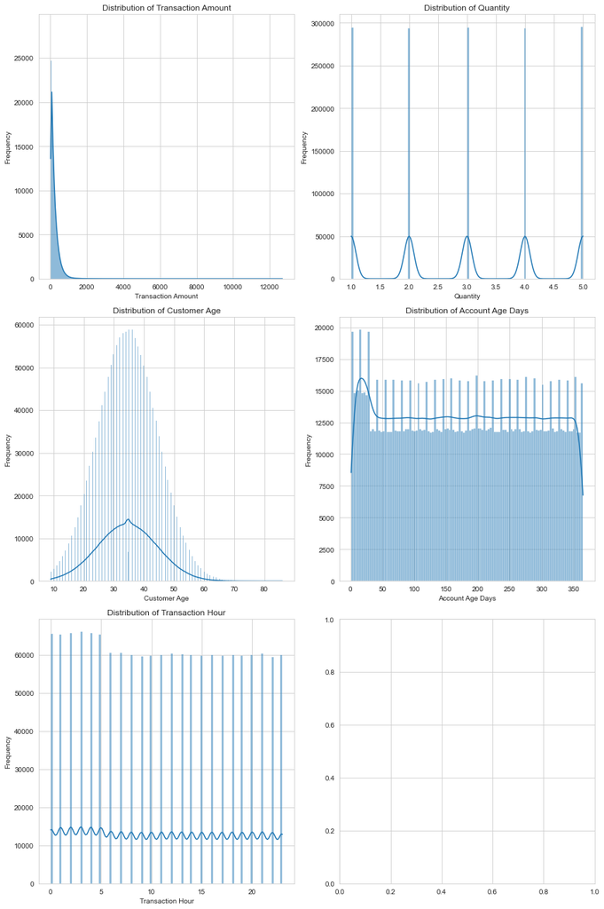

```python
import matplotlib.pyplot as plt
import seaborn as sns

# Set the style of seaborn
sns.set_style("whitegrid")

# Define numerical columns
numerical_cols = ['Transaction Amount', 'Quantity', 'Customer Age', 'Account Age Days', 'Transaction Hour']

# Calculate the number of rows needed for subplots
num_rows = (len(numerical_cols) + 1) // 2

# Create a 1 by 2 grid layout for the subplots
fig, axes = plt.subplots(num_rows, 2, figsize=(12, 6*num_rows))

# Iterate over each numerical column and create a histogram
for i, col in enumerate(numerical_cols):
    row = i // 2  # Calculate the row index
    c = i % 2   # Calculate the column index
    sns.histplot(train_df[col], kde=True, ax=axes[row, c])
    axes[row, c].set_title(f'Distribution of {col}')
    axes[row, c].set_xlabel(col)
    axes[row, c].set_ylabel('Frequency')

# Adjust layout to prevent overlap
plt.tight_layout()
plt.show()
```

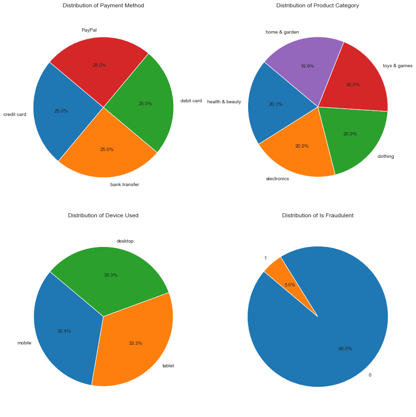

```python
# Explore categorical variables
categorical_cols = ['Payment Method', 'Product Category', 'Device Used', 'Is Fraudulent']

# Calculate the number of rows needed for subplots
num_rows = (len(categorical_cols) + 1) // 2

# Create a 1 by 2 grid layout for the subplots
fig, axes = plt.subplots(num_rows, 2, figsize=(12, 6*num_rows))

# Iterate over each categorical column and create a pie chart
for i, col in enumerate(categorical_cols):
    row = i // 2  # Calculate the row index
    c = i % 2   # Calculate the column index
    counts = train_df[col].value_counts()
    axes[row, c].pie(counts, labels=counts.index, autopct='%1.1f%%', startangle=140)
    axes[row, c].set_title(f'Distribution of {col}')
    axes[row, c].axis('equal')  # Equal aspect ratio ensures that pie is drawn as a circle

# Adjust layout to prevent overlap
plt.tight_layout()
plt.show()
```

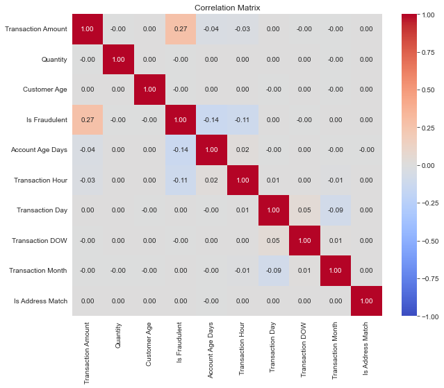

```python
# Calculate the correlation matrix
correlation_matrix = train_df.corr()

# Visualize the correlation matrix using a heatmap
plt.figure(figsize=(10, 8))
sns.heatmap(correlation_matrix, annot=True, cmap='coolwarm', fmt=".2f", vmin=-1, vmax=1)
plt.title('Correlation Matrix')
plt.show()
```

The correlation coefficient of 0.27 suggests a moderate postive relationship between 'Is fraudulent' and 'Transaction Amount'. This means that as the transaction amount increases, there is a tendency for the likelihood of the transaction being fraudulent to also increase. However, the strength of this relationship is not very strong.

Why did I choose Logistic regression?

### Logistic regression model (full model)

```python
import statsmodels.api as sm

# Separate features and target variable
X = train_df.drop(columns=['Is Fraudulent'])
y = train_df['Is Fraudulent']

# Perform one-hot encoding for categorical variables
X = pd.get_dummies(X, drop_first=True)

# Add constant term to the features (intercept)
X = sm.add_constant(X)

# Fit logistic regression model
model = sm.GLM(y, X, family=sm.families.Binomial())
result = model.fit()

# Print summary of the model
print(result.summary())
```

```
                 Generalized Linear Model Regression Results
==============================================================================
Dep. Variable:          Is Fraudulent   No. Observations:              1472952
Model:                            GLM   Df Residuals:                  1472933
Model Family:                Binomial   Df Model:                           18
Link Function:                  logit   Scale:                          1.0000
Method:                          IRLS   Log-Likelihood:            -2.4313e+05
Date:                Sun, 02 Jun 2024   Deviance:                   4.8626e+05
Time:                        16:04:33   Pearson chi2:                 1.70e+06
No. Iterations:                     7
Covariance Type:            nonrobust
====================================================================================================
                                       coef    std err          z      P>|z|      [0.025      0.975]
----------------------------------------------------------------------------------------------------
const                               -1.9679      0.029    -68.074      0.000      -2.025      -1.911
Transaction Amount                   0.0024   1.15e-05    206.286      0.000       0.002       0.002
Quantity                            -0.0032      0.003     -1.114      0.265      -0.009       0.002
Customer Age                        -0.0006      0.000     -1.440      0.150      -0.001       0.000
Account Age Days                    -0.0062   4.18e-05   -148.175      0.000      -0.006      -0.006
Transaction Hour                    -0.0776      0.001   -123.935      0.000      -0.079      -0.076
Transaction Day                  -1.519e-05      0.000     -0.033      0.973      -0.001       0.001
Transaction DOW                     -0.0001      0.002     -0.072      0.943      -0.004       0.004
Transaction Month                   -0.0044      0.005     -0.947      0.343      -0.014       0.005
Is Address Match                     0.0051      0.014      0.380      0.704      -0.021       0.032
Payment Method_bank transfer         0.0085      0.011      0.744      0.457      -0.014       0.031
Payment Method_credit card          -0.0099      0.011     -0.865      0.387      -0.032       0.013
Payment Method_debit card            0.0020      0.011      0.173      0.863      -0.020       0.024
Product Category_electronics        -0.0196      0.013     -1.527      0.127      -0.045       0.006
Product Category_health & beauty    -0.0060      0.013     -0.467      0.640      -0.031       0.019
Product Category_home & garden      -0.0074      0.013     -0.577      0.564      -0.033       0.018
Product Category_toys & games        0.0026      0.013      0.204      0.838      -0.022       0.028
Device Used_mobile                   0.0138      0.010      1.386      0.166      -0.006       0.033
Device Used_tablet                   0.0052      0.010      0.518      0.604      -0.014       0.025
====================================================================================================
```

From summary, we know that the variable 'Transaction Amount, 'Account Age Days' and 'Transaction Hour' are statistically significant at the significance level of 0.05.

```python
X_test = test_df.drop(columns=['Is Fraudulent'])
y_test = test_df['Is Fraudulent']

# Perform one-hot encoding for categorical variables
X_test = pd.get_dummies(X_test, drop_first=True)

# Add constant term to the features (intercept)
X_test = sm.add_constant(X_test)

y_test_pred_proba = result.predict(X_test)

# Convert predicted probabilities to binary predictions (0 or 1) using a threshold of 0.5
y_test_pred_binary = np.where(y_test_pred_proba >= 0.5, 1, 0)

# Calculate accuracy
accuracy = np.mean(y_test == y_test_pred_binary)

# Calculate confusion matrix
confusion_matrix = pd.crosstab(y_test, y_test_pred_binary, rownames=['Actual'], colnames=['Predicted'])

# Calculate precision, recall, and F1-score
true_positives = confusion_matrix.loc[1, 1]
false_positives = confusion_matrix.loc[0, 1]
false_negatives = confusion_matrix.loc[1, 0]

precision = true_positives / (true_positives + false_positives)
recall = true_positives / (true_positives + false_negatives)
f1_score = 2 * (precision * recall) / (precision + recall)

# Print the evaluation metrics
print("Accuracy:", accuracy)
print("Confusion Matrix:")
print(confusion_matrix)
print("Precision:", precision)
print("Recall:", recall)
print("F1-score:", f1_score)
```

```
Accuracy: 0.9531607006854531
Confusion Matrix:
Predicted      0    1
Actual
0          22386   26
1           1081  141
Precision: 0.844311377245509
Recall: 0.11538461538461539
F1-score: 0.20302375809935205
```

- Accuracy: The accuracy of the model is approximately 95.32%, indicating that around 95.32% of all transactions are correctly classified as fraudulent or non-fraudulent.
- Confusion Matrix:
  - True Negatives (TN): 22386 (non-fraudulent transactions correctly classified)
  - False Positives (FP): 26 (non-fraudulent transactions incorrectly classified as fraudulent)
  - False Negatives (FN): 1081 (fraudulent transactions incorrectly classified as non-fraudulent)
  - True Positives (TP): 141 (fraudulent transactions correctly classified)
- Precision: The precision of the model is approximately 84.43%, indicating that among all transactions predicted as fraudulent, around 84.43% are truly fraudulent.
- Recall: The recall (or sensitivity) of the model is approximately 11.54%, indicating that only around 11.54% of all fraudulent transactions are correctly identified by the model.
- F1-score: The F1-score of the model is approximately 20.30%, which is the harmonic mean of precision and recall. It provides a balance between precision and recall and is useful when there is an uneven class distribution.

### Random Forest Classifier (Full model)

```python
from sklearn.ensemble import RandomForestClassifier
from sklearn.metrics import accuracy_score, precision_score, recall_score, f1_score

# Instantiate Random Forest classifier model
rf_model = RandomForestClassifier(n_estimators=100, random_state=42)

# Fit Random Forest model on the training data
rf_model.fit(X, y)
# Predict using Random Forest model
rf_y_pred = rf_model.predict(X_test)

# Evaluate performance of Random Forest model
rf_accuracy = accuracy_score(y_test, rf_y_pred)
rf_precision = precision_score(y_test, rf_y_pred)
rf_recall = recall_score(y_test, rf_y_pred)
rf_f1 = f1_score(y_test, rf_y_pred)

print("Performance of Random Forest model:")
print("Accuracy:", rf_accuracy)
print("Precision:", rf_precision)
print("Recall:", rf_recall)
print("F1-score:", rf_f1)
```

```
Performance of Random Forest model:
Accuracy: 0.9538800033849539
Precision: 0.7727272727272727
Recall: 0.1530278232405892
F1-score: 0.25546448087431695
```

```python
# Get feature importances
feature_importances = rf_model.feature_importances_
feature_names = X.columns

# Create a DataFrame for feature importances
importances_df = pd.DataFrame({'Feature': feature_names, 'Importance': feature_importances})

# Sort the DataFrame by importance
importances_df = importances_df.sort_values(by='Importance', ascending=False)

# Print the top 10 important features
print("Top 5 Important Features:")
print(importances_df.head(5))
```

```
Top 5 Important Features:
              Feature  Importance
1  Transaction Amount    0.276945
4    Account Age Days    0.208694
3        Customer Age    0.115055
5    Transaction Hour    0.096897
6     Transaction Day    0.078195
```

Both models shows that the 'Transaction Amount, 'Account Age Days' and 'Transaction Hour' are important features.

Based on these comparisons, if the goal is to prioritize precision (minimize false positives) while maintaining a reasonable level of recall, the logistic regression model may be preferred due to its higher precision. However, if maximizing recall (capturing as many fraudulent transactions as possible) is more important, the Random Forest model may be favored due to its higher recall and slightly higher F1-score.